# Observing the Relation of SNPs to Disease

Using machine learning, we will determine the relationship of Single Nucleotide Polymorphism (SNP) to disease. This report specifies respective model accuracy in addition to providing insight for further genomic analysis. We use random forests, logistic regression, support vector machines, and neural networks to classify the presence of disease based on the number of mutated alleles found in 10 distinct positions.

## Data Preprocessing

The .arff is loaded into a data set using scipy's loadarff module. It is then split into a training and target (or testing). The training set is later combined into a pandas dataframe. The data is converted to int64s and NA values are removed. We describe each variable in addition to displaying their histogram.

```
         location1   location10    location2    location3    location4  \
count  2000.000000  2000.000000  2000.000000  2000.000000  2000.000000
mean      0.573500     0.981000     0.483000     0.750000     0.380000
std       0.645605     0.645637     0.605718     0.691187     0.561032
min       0.000000     0.000000     0.000000     0.000000     0.000000
25%       0.000000     1.000000     0.000000     0.000000     0.000000
50%       0.000000     1.000000     0.000000     1.000000     0.000000
75%       1.000000     1.000000     1.000000     1.000000     1.000000
max       2.000000     2.000000     2.000000     2.000000     2.000000

         location5    location6    location7    location8    location9
count  2000.000000  2000.000000  2000.000000  2000.000000  2000.000000
mean      1.011000     0.688000     0.489000     0.317500     0.652500
std       0.652757     0.677411     0.613243     0.517521     0.669304
min       0.000000     0.000000     0.000000     0.000000     0.000000
25%       1.000000     0.000000     0.000000     0.000000     0.000000
50%       1.000000     1.000000     0.000000     0.000000     1.000000
75%       1.000000     1.000000     1.000000     1.000000     1.000000
max       2.000000     2.000000     2.000000     2.000000     2.000000
```

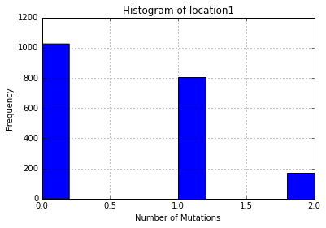

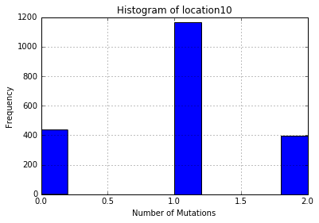

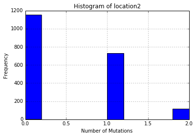

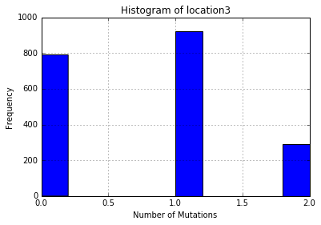

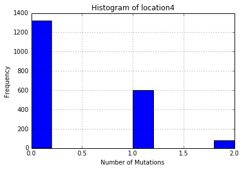

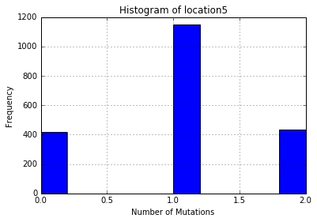

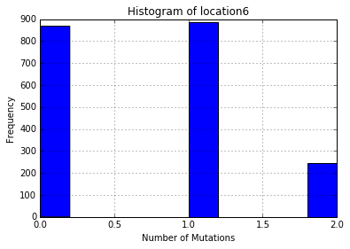

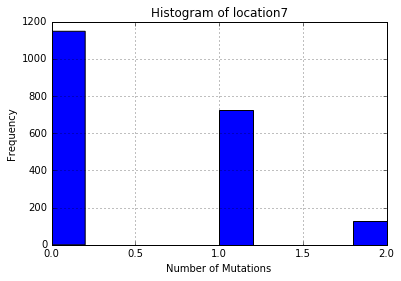

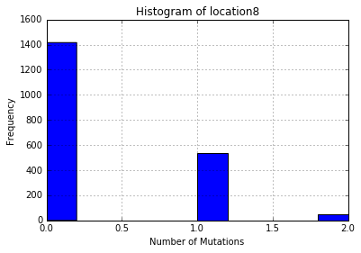

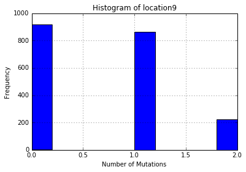

```python
%matplotlib inline
from __future__ import division
from scipy.io.arff import loadarff
from ggplot import *
import scipy as sp
import numpy as np
import pandas as pd
from sklearn import svm
import matplotlib.pyplot as plt
from sklearn.ensemble import RandomForestClassifier
from sklearn.metrics import confusion_matrix
from sklearn.metrics import roc_auc_score
from sklearn.linear_model import LogisticRegression
from sklearn.grid_search import GridSearchCV
from sklearn import metrics
from sklearn.metrics import auc, roc_curve

# load data and convert arff to dataframe
dataset, meta = loadarff(open('disease2a.arff','r'))
target= np.array(dataset[['class']])
train = np.array(dataset[['location1','location2','location3','location4', 'location5','location6','location7','location8', 'location9','location10']])

df = pd.DataFrame({'location1' : train['location1'], 'location2' : train['location2'],
                   'location3' : train['location3'], 'location4' : train['location4'],
                   'location5' : train['location5'], 'location6' : train['location6'],
                   'location7' : train['location7'], 'location8' : train['location8'],
                   'location9' : train['location9'], 'location10': train['location10']}, index = list(range(1,len(train)+1)))

target = pd.Series(target, index= list(range(1,len(target)+1)), dtype='int64')

#drop any na values
df.dropna()

# change all types to ints
for col in df.columns:
    df.loc[:, col] = df[col].astype(np.int64)

# get summary stats and histograms for each var
print df.describe()
for col in df.columns:
    df.hist(col)
    plt.xlabel('Number of Mutations')
    plt.ylabel('Frequency')
    plt.title('Histogram of %s'% col)

#We'll allot 70% of our data to be training, and the other 30% to be testing
n_train = int((0.7*len(train)))

#create array of models for accuracy, auc
all_acc = {}
all_auc = {}
```

## Model Comparisons

For each model, we will predict the presence of the disease using a binary classification method that incorporating all SNP predictors. Their respective performance is evaulated using auc scoring, observing its confusion matrix, and mean accuracy.

### Random Forests

```
===========RANDOM FOREST===========
Confusion Matrix:
[[203  85]
 [ 51 261]]
Mean accuracy:  0.773333333333
AUC:  0.805661280271
Feature importance ranking:

location1 : 0.0603256493717
location10 : 0.176469476888
location2 : 0.060458675426
location3 : 0.0731605103639
location4 : 0.0695367562656
location5 : 0.275026367819
location6 : 0.0863178691262
location7 : 0.0714761618558
location8 : 0.053616953842
location9 : 0.0736115790422
```

[output not shown]

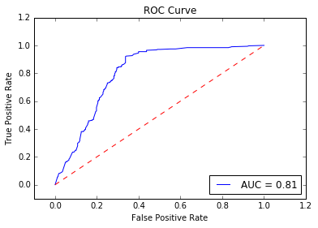

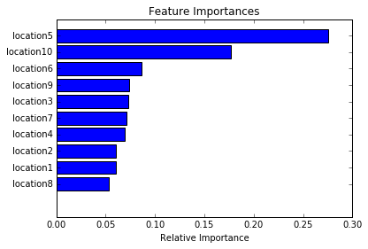

```python
# no need to permute data since random forest takes random samples
x_train, x_train_target  = df[:n_train], target[:n_train]
x_test, x_test_target = df[n_train:], target[n_train:]

print "===========RANDOM FOREST==========="
rf = RandomForestClassifier(n_estimators=25, verbose=1)
rf.fit(x_train, x_train_target)

#confusion matrix
x_test_predict_proba = rf.predict_proba(x_test)[:,1]
x_test_predict = rf.predict(x_test)
cm = confusion_matrix(x_test_target, x_test_predict)
print "Confusion Matrix: \n",cm

#mean accuracy
acc = rf.score(x_test, x_test_target)
print "Mean accuracy: ",acc
all_acc["RandomF"] = acc

#auc and roc curve
false_positive_rate, true_positive_rate, thresholds = roc_curve(x_test_target, x_test_predict_proba)
roc_auc = auc(false_positive_rate, true_positive_rate)
print "AUC: ", roc_auc
all_auc["RandomF"] = roc_auc
plt.figure(1)
plt.title('ROC Curve')
plt.plot(false_positive_rate, true_positive_rate, 'b',label='AUC = %0.2f'% roc_auc)
plt.legend(loc='lower right')
plt.plot([0,1],[0,1],'r--')
plt.xlim([-0.1,1.2])
plt.ylim([-0.1,1.2])
plt.ylabel('True Positive Rate')
plt.xlabel('False Positive Rate')

#feature importance
print "Feature importance ranking: \n"
feature_imp = rf.feature_importances_

for x in range (0, len(feature_imp)):
    print x_train.columns[x],":", feature_imp[x]

importances = rf.feature_importances_
indices = np.argsort(importances)
plt.figure(2)
plt.title('Feature Importances')
plt.barh(range(len(indices)), importances[indices], color='b', align='center')
plt.yticks(range(len(indices)), x_train[indices])
plt.xlabel('Relative Importance')
```

### Logistic Regression

```
===========LOGISTIC REGRESSION===========
Mean accuracy:  0.613333333333
Confusion Matrix:
[[103 185]
 [ 47 265]]
AUC:  0.542690527066
```

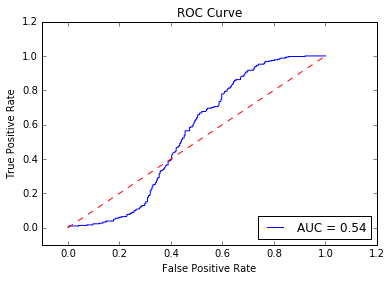

```python
#randomize the sampling
np.random.seed(0)
df.reindex(np.random.permutation(df.index))
x_train, x_train_target = df[:n_train], target[:n_train]
x_test, x_test_target = df[n_train:], target[n_train:]

print "\n===========LOGISTIC REGRESSION==========="
logreg = LogisticRegression()
logreg.fit(x_train, x_train_target)

#mean accuracy
acc = logreg.score(x_test, x_test_target)
print "Mean accuracy: ",acc
all_acc["logReg"] = acc

#confusion matrix
x_test_predict_proba = logreg.predict_proba(x_test)[:,1]
x_test_predict = logreg.predict(x_test)
cm = confusion_matrix(x_test_target, x_test_predict)
print "Confusion Matrix: \n",cm

#auc and roc curve
false_positive_rate, true_positive_rate, thresholds = roc_curve(x_test_target, x_test_predict_proba)
roc_auc = auc(false_positive_rate, true_positive_rate)
print "AUC: ", roc_auc
all_auc["logReg"] = roc_auc
plt.figure(1)
plt.title('ROC Curve')
plt.plot(false_positive_rate, true_positive_rate, 'b',label='AUC = %0.2f'% roc_auc)
plt.legend(loc='lower right')
plt.plot([0,1],[0,1],'r--')
plt.xlim([-0.1,1.2])
plt.ylim([-0.1,1.2])
plt.ylabel('True Positive Rate')
plt.xlabel('False Positive Rate')
```

### Support Vector Machine

The SVM models are run using 2 different kernels: RBF (radial basis function) and the polynomial kernel.

### RBF Kernel

The RBF Kernel model provides a mean classification accuracy of 80%, the highest of all models so far. Based off the confusion matrix, the model's ability to recall (sensitivity) is 95%. It has a precision accuracy of 74% and a specificity of 64%. The ROC curve plotted below has an AUC of 83%, the highest AUC so far. After using a cross-validation grid search to find the best gamma and C parameters, the best model has a C = 10 and gamma = 0.1.

```
===RBF KERNEL===
Best classifier with rbf kernel:
SVC(C=10, cache_size=200, class_weight=None, coef0=0.0,
  decision_function_shape=None, degree=3, gamma=0.1, kernel='rbf',
  max_iter=-1, probability=True, random_state=None, shrinking=True,
  tol=0.001, verbose=False)

Mean accuracy:  0.803333333333
Confusion Matrix:
[[185 103]
 [ 15 297]]
AUC:  0.828759348291
```

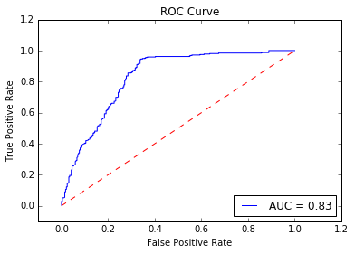

```python
print "===RBF KERNEL==="
#randomize sampling
np.random.seed(0)
df.reindex(np.random.permutation(df.index))
x_train, x_train_target = df[:n_train], target[:n_train]
x_test, x_test_target = df[n_train:], target[n_train:]

#set c_range and gamma range for grid search
C_range = [0.01,0.1, 1, 10]
gamma_range = [0.01,0.1, 1, 10]
param_grid = dict(C=C_range, gamma=gamma_range)
svr = svm.SVC(kernel='rbf', probability = True)
grid = GridSearchCV(svr, param_grid)
grid.fit(x_train, x_train_target)
print "Best classifier with rbf kernel: \n", grid.best_estimator_
print

#mean accuracy
acc = grid.score(x_test, x_test_target)
print "Mean accuracy: ",acc
all_acc["SVM-rbf"] = acc

#confusion matrix
x_test_predict_proba = grid.predict_proba(x_test)[:,1]
x_test_predict = grid.predict(x_test)
cm = confusion_matrix(x_test_target, x_test_predict)
print "Confusion Matrix: \n",cm

#auc and roc curve
false_positive_rate, true_positive_rate, thresholds = roc_curve(x_test_target, x_test_predict_proba)
roc_auc = auc(false_positive_rate, true_positive_rate)
print "AUC: ", roc_auc
all_auc["SVM-rbf"] = roc_auc
plt.figure(1)
plt.title('ROC Curve')
plt.plot(false_positive_rate, true_positive_rate, 'b',label='AUC = %0.2f'% roc_auc)
plt.legend(loc='lower right')
plt.plot([0,1],[0,1],'r--')
plt.xlim([-0.1,1.2])
plt.ylim([-0.1,1.2])
plt.ylabel('True Positive Rate')
plt.xlabel('False Positive Rate')
```

#### Polynomial Kernel

The Polynomial Kernel model provides a mean classification accuracy of 63%, the lowest mean accuracy after logisitic regression. Based off the confusion matrix, the model's ability to recall (sensitivity) is 94%. It has a precision accuracy of 59% and a specificity of 29%. The ROC curve plotted below has an AUC of 69%, the lowest after logistic regression. After using a cross-validation grid search to find the best C and degree parameters, the best model has a C = 1 and degree = 4.

```
===POLY KERNEL===
Best classifier with poly kernel:
SVC(C=1, cache_size=200, class_weight=None, coef0=0.0,
  decision_function_shape=None, degree=4, gamma='auto', kernel='poly',
  max_iter=-1, probability=True, random_state=None, shrinking=True,
  tol=0.001, verbose=False)

Mean accuracy:  0.631666666667
Confusion Matrix:
[[ 85 203]
 [ 18 294]]
AUC:  0.688529424858
```

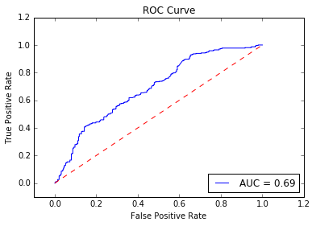

```python
print "===POLY KERNEL==="
#randomize the sampling
np.random.seed(0)
df.reindex(np.random.permutation(df.index))
x_train, x_train_target = df[:n_train], target[:n_train]
x_test, x_test_target = df[n_train:], target[n_train:]

#set c_range and degree range for grid search
C_range = [0.001,0.01,0.1, 1]
degree_range = [1,2,3,4]
param_grid = dict(C=C_range, degree= degree_range)
svr = svm.SVC(kernel='poly', probability = True)
grid = GridSearchCV(svr, param_grid)
grid.fit(x_train, x_train_target)
print "Best classifier with poly kernel: \n", grid.best_estimator_
print

#mean accuracy
acc = grid.score(x_test, x_test_target)
print "Mean accuracy: ",acc
all_acc["SVM-poly"] = acc

#confusion matrix
x_test_predict_proba = grid.predict_proba(x_test)[:,1]
x_test_predict = grid.predict(x_test)
cm = confusion_matrix(x_test_target, x_test_predict)
print "Confusion Matrix: \n",cm

#auc and roc curve
false_positive_rate, true_positive_rate, thresholds = roc_curve(x_test_target, x_test_predict_proba)
roc_auc = auc(false_positive_rate, true_positive_rate)
print "AUC: ", roc_auc
all_auc["SVM-poly"] = roc_auc
plt.figure(1)
plt.title('ROC Curve')
plt.plot(false_positive_rate, true_positive_rate, 'b',label='AUC = %0.2f'% roc_auc)
plt.legend(loc='lower right')
plt.plot([0,1],[0,1],'r--')
plt.xlim([-0.1,1.2])
plt.ylim([-0.1,1.2])
plt.ylabel('True Positive Rate')
plt.xlabel('False Positive Rate')
```